# Figures 1 and 2

## Multi-engine rescoring pipeline results (no quantification!).

This workflow uses MSFragger Comet, Sage, PEAKS Studio 12.5 with follow-up TIMS2Rescore rescoring (Willems et al. 2025, JPR). Compared to the previous published analysis of this data, PEAKS Studio 12.5 was now used instead of PEAKS Studio 12.0. The generated peptides.txt read in here combines the aggregated results of all four rescored search engine results at a mokapot peptide 1% Q-value.

```python
import pandas as pd

df = pd.read_csv('pipeline_ddaPASEF_peptides.txt',sep='\t')
pipelineDDA_peps = set(df['peptide'].unique())
```

## Read in human proteins, contaminants and cRAP db.

All human UniProtKB protein sequences, the cRAP database and the nuORFdb (Ouspenskaia et al., 2018 Nat Biotechnol) is queried to ensure bacterial peptide sequences do no match non-canonical proteins. Ile is substituted to Leu as these have the same mass, bacterial peptides will be similarly checked after replacing I->L later.

```python
from Bio import SeqIO

fasta_path = 'human_uniprotKB_nuORFdb_cRAP_ItoL.fasta'
records = list(SeqIO.parse(fasta_path, "fasta"))
protein_dict = {record.id: str(record.seq) for record in records}
```

## Spectronaut 19 directDIA search.

Regular directDIA search was ran on the 8 diaPASEF runs, searching for peptides of 7-20 AA long, variable methionine oxidation and N-terminal protein acetylation (max 1 mod per peptide). Protein FDR was set at 100% for identification and quantification as immunopeptidomics operates at peptide FDR level. A default peptide report was exported, adding the PEP.StrippedSequence and additional protein information columns.

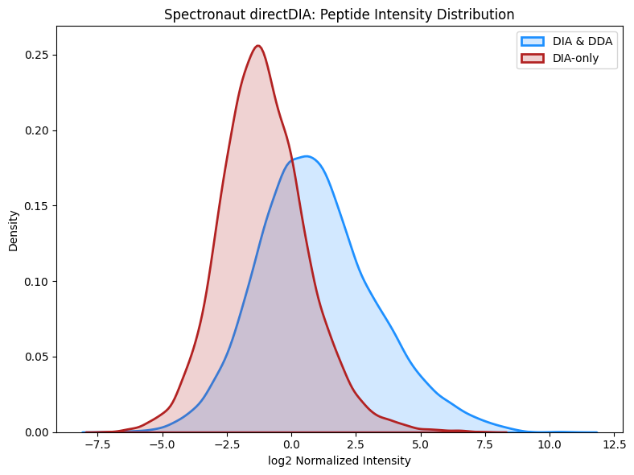

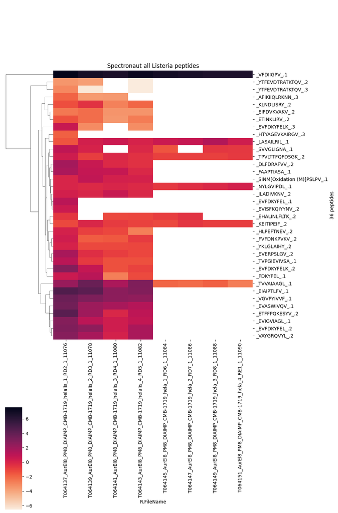

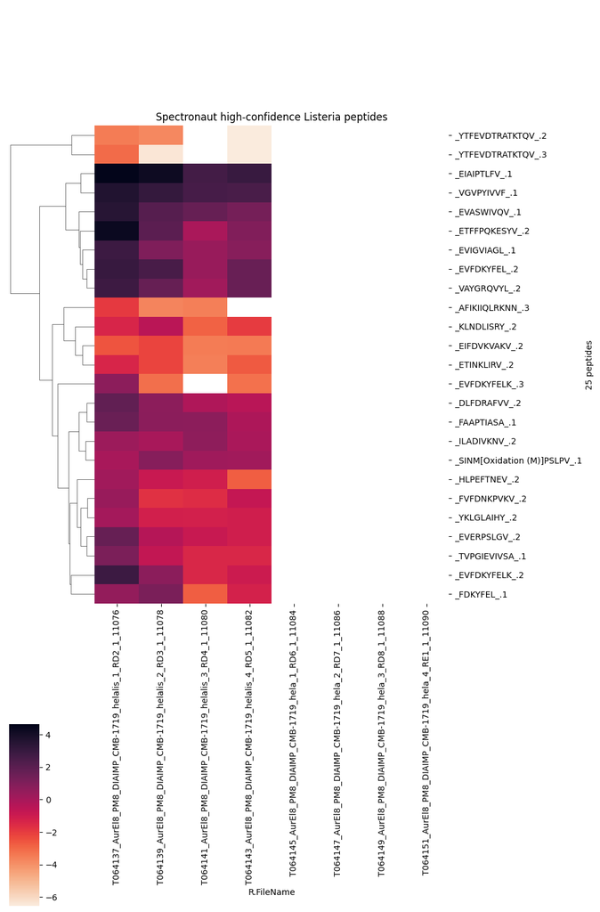

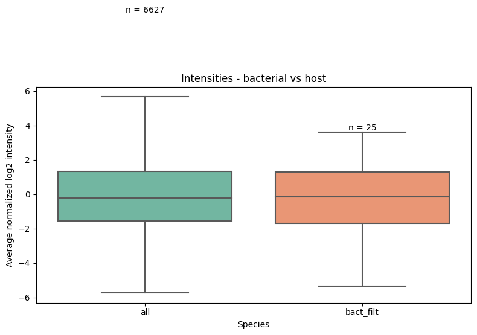

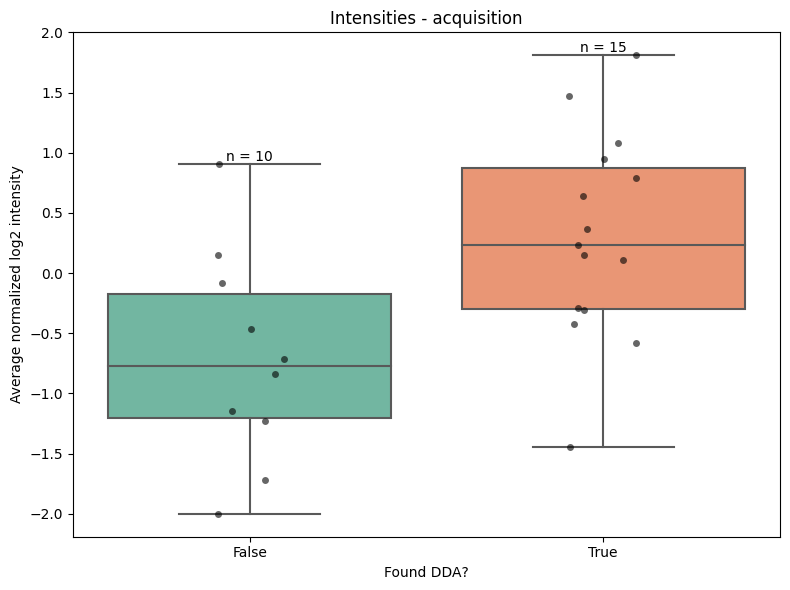

```python
import pandas as pd
import seaborn as sns
import matplotlib.pyplot as plt
import numpy as np

# Read Spectronaut report and get unique peptide sequences identified.
df = pd.read_csv('20250329_133719_T064137_proteinFDR_1_Report.tsv',sep='\t',decimal=',')
spectronaut_peps = set(df['PEP.StrippedSequence'].unique())

# Log2 transform.
df["log2_int"] = np.log2(df["EG.TotalQuantity (Settings)"])

# Peptide found in DDA or not
df['dda'] = df['PEP.StrippedSequence'].isin(pipelineDDA_peps)

# Pivot intensities
pivot_df = df.pivot_table(
    index=['EG.PrecursorId', 'PG.ProteinAccessions','PG.ProteinDescriptions','PG.ProteinNames','PG.Organisms','PEP.StrippedSequence','dda'],
    columns='R.FileName',
    values='log2_int'
)

# Median normalize per sample (column-wise)
pivot_df = pivot_df.subtract(pivot_df.median(axis=0), axis=1)

# Save matrix
pivot_df.to_csv('Spectronaut_directDIA_matrix.tsv',sep='\t')

# KDE plot intensities DIA-only vs DDA
dia_dda = pivot_df[pivot_df.index.get_level_values('dda')].values.flatten()
dia_only = pivot_df[~pivot_df.index.get_level_values('dda')].values.flatten()
dia_dda = dia_dda[~np.isnan(dia_dda)]
dia_only = dia_only[~np.isnan(dia_only)]
plt.figure(figsize=(8, 6))
sns.kdeplot(dia_dda, fill=True, label="DIA & DDA", color="dodgerblue", linewidth=2, alpha=0.2)
sns.kdeplot(dia_only, fill=True, label="DIA-only", color="firebrick", linewidth=2, alpha=0.2)
plt.xlabel("log2 Normalized Intensity")
plt.ylabel("Density")
plt.title("Spectronaut directDIA: Peptide Intensity Distribution")
plt.legend()
plt.tight_layout()
plt.savefig('Spectronaut_directDIA_int.svg')
plt.savefig('Spectronaut_directDIA_int.png', dpi=600)
plt.show()
plt.clf()
plt.close()

## FIGURE 5
# Bacterial peptide filtering
bact_df = pivot_df[pivot_df.index.get_level_values('PG.Organisms') == 'Listeria monocytogenes serotype 1/2a (strain EGD / Mackaness)']
spectronaut_bact_peps = bact_df.index.get_level_values('PEP.StrippedSequence').unique()
bact_peptides_ItoL = [pep.replace('I', 'L') for pep in spectronaut_bact_peps] # Isobaric

# Filter 1: check for matching human/contaminant/nuORF db protein
bact_peptide_check = {}
for pep in bact_peptides_ItoL:
    matching_proteins = [prot_id for prot_id, seq in protein_dict.items() if pep in seq]

    if matching_proteins:  # If there are any matching proteins
        bact_peptide_check[pep] = matching_proteins
        print(f'{pep} matched {matching_proteins}!')
    else:
        bact_peptide_check[pep] = 'No_match'

#Get infected and uninfected columns and fill zeroes.
inf_cols = [col for col in bact_df.columns if "_helalis_" in col]
uninf_cols = [col for col in bact_df.columns if "_hela_" in col]
bact_df.fillna(0, inplace=True)  # Set to zero for clustering and filtering, will be masked later.

# Plot heatmap of all bacterial peptides
mask = bact_df == 0
yticklabels = bact_df.index.get_level_values(0)
g = sns.clustermap(
    bact_df,
    cmap="rocket_r",  # Choose a color map
    col_cluster=False,  # Do not cluster columns (R.FileName)
    figsize=(10, 15),  # Adjust figure size
    mask=mask,
    yticklabels=yticklabels,
    cbar_pos=(0.02, 0, 0.05, 0.2)
)
g.ax_heatmap.set_ylabel(f'{len(bact_df)} peptides')
g.ax_heatmap.set_title('Spectronaut all Listeria peptides')
plt.savefig('Spectronaut_directDIA_bact_heatmap_all.svg')
plt.savefig('Spectronaut_directDIA_bact_heatmap_all.png',dpi=600)
plt.show()

# Filter 2: at least quantified twice in the infected condition, absent in the uninfected
bact_df_filt = bact_df[
    ((bact_df[inf_cols] != 0).sum(axis=1) >= 2) &  # Quantified twice in infection
    ((bact_df[uninf_cols] == 0).all(axis=1))           # All zero values in hela
]
spectronaut_bact_peps_filt = bact_df_filt.index.get_level_values('PEP.StrippedSequence').unique()
mask = bact_df_filt == 0
yticklabels = bact_df_filt.index.get_level_values(0)
g = sns.clustermap(
    bact_df_filt,
    cmap="rocket_r",  # Choose a color map
    col_cluster=False,  # Do not cluster columns (R.FileName)
    figsize=(10, 15),  # Adjust figure size
    mask=mask,
    yticklabels=yticklabels,
    cbar_pos=(0.02, 0, 0.05, 0.2)
)
g.ax_heatmap.set_ylabel(f'{len(bact_df_filt)} peptides')
g.ax_heatmap.set_title('Spectronaut high-confidence Listeria peptides')
plt.savefig('Spectronaut_directDIA_bact_heatmap_filt.svg')
plt.savefig('Spectronaut_directDIA_bact_heatmap_filt.png',dpi=600)
plt.show()

# Print out the information of the bacterial peptides ordered as in the clustermap
precursors_plotted = [bact_df_filt.index[i] for i in g.dendrogram_row.reordered_ind]
with open("Spectronaut_directDIA_bact_heatmap_filt_ylabels.txt", "w") as f:
    for prec in precursors_plotted:
        f.write("\t".join(map(str, prec)) + "\n")

## Boxplot of quantifications
# High-confidence bacterial peptides versus all peptides
row_means = pivot_df.mean(axis=1, skipna=True)
bact_filt_means = row_means[row_means.index.isin(bact_df_filt.index)]
plot_df = pd.DataFrame({
    'mean_intensity': pd.concat([row_means,bact_filt_means], ignore_index=True),
    'group': (['all'] * len(row_means)) + (['bact_filt'] * len(bact_filt_means))
})

# Plot
plt.figure(figsize=(8, 6))
sns.boxplot(x='group', y='mean_intensity', data=plot_df, palette="Set2",showfliers=False)
plt.title("Intensities - bacterial vs host")
plt.ylabel("Average normalized log2 intensity")
plt.xlabel("Species")
for i, grp in enumerate(['all', 'bact_filt']):
    n = plot_df[plot_df['group'] == grp].shape[0]
    ymax = plot_df[plot_df['group'] == grp]['mean_intensity'].max()
    plt.text(i, ymax, f"n = {n}", ha='center', va='bottom')
plt.tight_layout()
plt.savefig('Spectronaut_directDIA_bact_host_int_boxplot.svg')
plt.savefig('Spectronaut_directDIA_bact_host_int_boxplot.png',dpi=600)
plt.show()
plt.clf()
plt.close()

# High-confidence bacterial peptides: DDA vs DIA-only spectrum-centric vs uniquely peptide-centric
# Calculate row means
bact_df_filt['row_mean'] = bact_df_filt.mean(axis=1, skipna=True)
df_plot = bact_df_filt.copy()
df_plot = df_plot.reset_index()
# Create plot
plt.figure(figsize=(8, 6))
sns.boxplot(x='dda', y='row_mean', data=df_plot, palette='Set2',showfliers=False)
sns.stripplot(x='dda', y='row_mean', data=df_plot, color='black', alpha=0.6, jitter=True, dodge=True)  # Add jitter (jitter = True)
plt.title('Intensities - acquisition')
plt.xlabel('Found DDA?')
plt.ylabel('Average normalized log2 intensity')

# Add n annotations
for i, grp in enumerate(df_plot['dda'].unique()):
    n = (df_plot['dda'] == grp).sum()
    ymax = df_plot[df_plot['dda'] == grp]['row_mean'].max()
    plt.text(i, ymax, f'n = {n}', ha='center', va='bottom')

plt.tight_layout()
plt.savefig('Spectronaut_directDIA_bact_dda_int_boxplot.svg')
plt.savefig('Spectronaut_directDIA_bact_dda_int_boxplot.png',dpi=600)
plt.show()
plt.clf()
plt.close()
```

## FragPipe directDIA coupled to DIA-NN 2.0.2

diaTracer was ran and pseudo-MS/MS were searched with MSFragger, searching for peptides of 7-20 AA long, variable methionine oxidation and N-terminal protein acetylation (max 1 mod per peptide). MSBooster was used for re-scoring and easypqp for spectral library building. Protein FDR is by default set at 100% in the HLA-immunopeptidome workflows. The generated library.tsv was searched with DIA-NN v2.0.2 in generic scoring mode for quantification. The parquet report is used here.

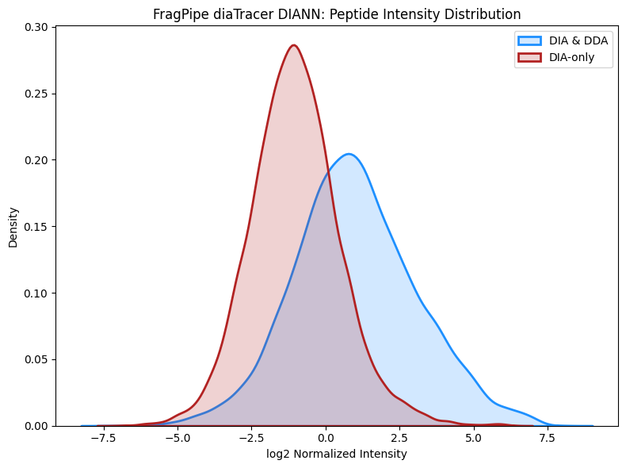

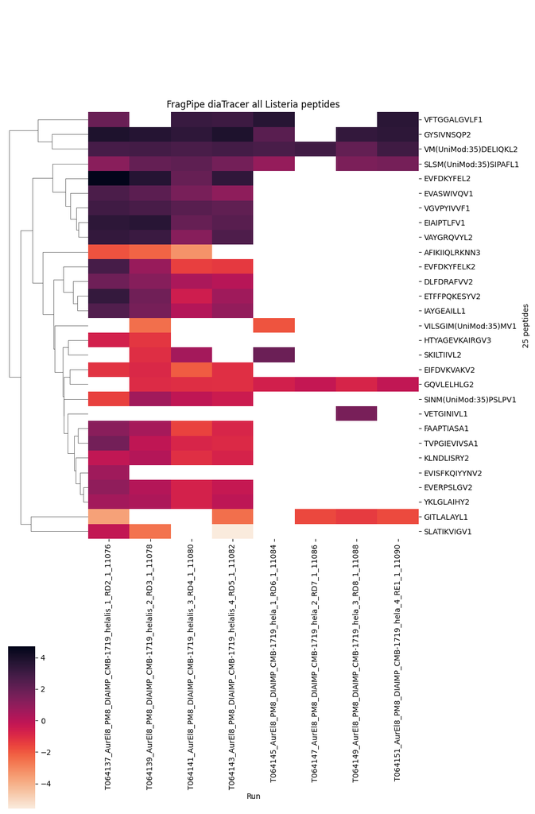

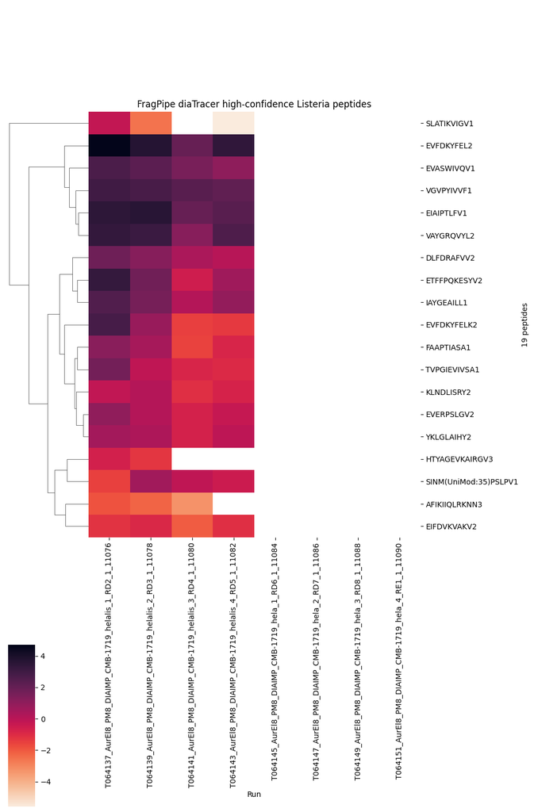

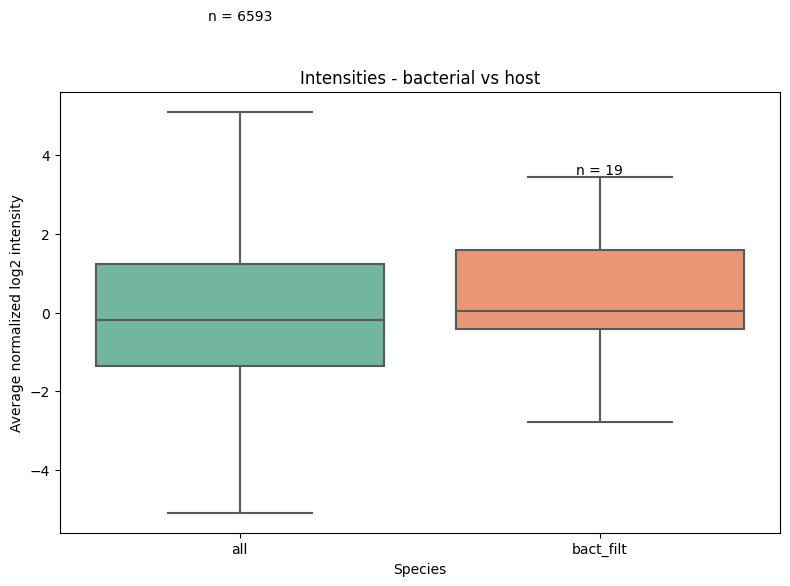

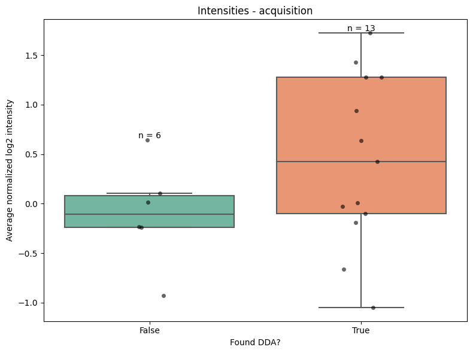

```python
import pandas as pd
import numpy as np
from Bio import SeqIO
from tqdm import tqdm
import sys

# We will re-map the stripped.sequences.
fasta_path = 'EGD_human.fasta'
records = list(SeqIO.parse(fasta_path, "fasta"))
fasta_dict = {record.id: str(record.seq) for record in records}

# Read DIA-NN main report and get unique sequences.
df = pd.read_parquet('fragpipe_diann_report.parquet')
fragpipe_peps = set(df["Stripped.Sequence"].unique())

# Map the sequences to proteins
mapping_dict = {}
for pep in tqdm(fragpipe_peps, desc="Mapping peptides to proteins"):
    matching_proteins = [prot_id for prot_id, seq in fasta_dict.items() if pep in seq]
    mapping_dict[pep] = ";".join(matching_proteins) if matching_proteins else "No_match"
df['Mapped_Proteins'] = df['Stripped.Sequence'].apply(lambda pep: mapping_dict.get(pep, 'No_match'))

# Log2 transform.
df["log2_int"] = np.log2(df["Precursor.Normalised"])

# Peptide found in DDA or not
df['dda'] = df['Stripped.Sequence'].isin(pipelineDDA_peps)

# Pivot intensities.
pivot_df = df.pivot_table(
    index=['Precursor.Id', 'Protein.Ids','Protein.Names','Mapped_Proteins','Genes','Stripped.Sequence','dda'],
    columns='Run',
    values='log2_int'
)

# Median normalize per sample (column-wise)
pivot_df = pivot_df.subtract(pivot_df.median(axis=0), axis=1)

# Save matrix.
pivot_df.to_csv('FragPipe_diaTracer_DIANN_matrix.tsv',sep='\t') # Save values.

# Density plot of DIA-only peptides and those also found by ddaPASEF.
dia_dda = pivot_df[pivot_df.index.get_level_values('dda')].values.flatten()
dia_only = pivot_df[~pivot_df.index.get_level_values('dda')].values.flatten()
dia_dda = dia_dda[~np.isnan(dia_dda)]
dia_only = dia_only[~np.isnan(dia_only)]
plt.figure(figsize=(8, 6))
sns.kdeplot(dia_dda, fill=True, label="DIA & DDA", color="dodgerblue", linewidth=2, alpha=0.2)
sns.kdeplot(dia_only, fill=True, label="DIA-only", color="firebrick", linewidth=2, alpha=0.2)
plt.xlabel("log2 Normalized Intensity")
plt.ylabel("Density")
plt.title("FragPipe diaTracer DIANN: Peptide Intensity Distribution")
plt.legend()
plt.tight_layout()
plt.savefig('FragPipe_diaTracer_DIANN_int.svg')
plt.savefig('FragPipe_diaTracer_DIANN_int.png', dpi=600)
plt.show()
plt.clf()
plt.close()

## FIGURE 5
# Bacterial peptide filtering
bact_df = pivot_df[
    (pivot_df.index.get_level_values('Mapped_Proteins').str.contains('_LISMG')) &
    (~pivot_df.index.get_level_values('Mapped_Proteins').str.contains('_HUMAN'))
]
fragpipe_bact_peps = bact_df.index.get_level_values('Stripped.Sequence').unique()
bact_peptides_ItoL = [pep.replace('I', 'L') for pep in fragpipe_bact_peps] # Isobaric

# Filter 1: check for matching human/contaminant/nuORF db protein
bact_peptide_check = {}
for pep in bact_peptides_ItoL:
    matching_proteins = [prot_id for prot_id, seq in protein_dict.items() if pep in seq]

    if matching_proteins:  # If there are any matching proteins
        bact_peptide_check[pep] = matching_proteins
        print(f'{pep} matched {matching_proteins}!')
    else:
        bact_peptide_check[pep] = 'No_match'

# Get infected and uninfected and fill zeroes.
inf_cols = [col for col in bact_df.columns if "_helalis_" in col]
uninf_cols = [col for col in bact_df.columns if "_hela_" in col]
bact_df.fillna(0, inplace=True)  # Set to zero for clustering and filtering, will be masked later.

# Plot heatmap of all bacterial peptides.
mask = bact_df == 0
yticklabels = bact_df.index.get_level_values(0)
g = sns.clustermap(
    bact_df,
    cmap="rocket_r",  # Choose a color map
    col_cluster=False,  # Do not cluster columns (R.FileName)
    figsize=(10, 15),  # Adjust figure size
    mask=mask,
    yticklabels=yticklabels,
    cbar_pos=(0.02, 0, 0.05, 0.2)
)
g.ax_heatmap.set_ylabel(f'{len(bact_df_filt)} peptides')
g.ax_heatmap.set_title('FragPipe diaTracer all Listeria peptides')
plt.savefig('FragPipe_diaTracer_DIANN_bact_heatmap_all.svg')
plt.savefig('FragPipe_diaTracer_DIANN_bact_heatmap_all.png',dpi=600)
plt.show()

# Filter 2: at least quantified twice in the infected condition, absent in the uninfected
bact_df_filt = bact_df[
    ((bact_df[inf_cols] != 0).sum(axis=1) >= 2) &  # Quantified twice in infection
    ((bact_df[uninf_cols] == 0).all(axis=1))           # All zero values in hela
]
fragpipe_bact_peps_filt = bact_df_filt.index.get_level_values('Stripped.Sequence').unique()
mask = bact_df_filt == 0
yticklabels = bact_df_filt.index.get_level_values(0)
g = sns.clustermap(
    bact_df_filt,
    cmap="rocket_r",  # Choose a color map
    col_cluster=False,  # Do not cluster columns (R.FileName)
    figsize=(10, 15),  # Adjust figure size
    mask=mask,
    yticklabels=yticklabels,
    cbar_pos=(0.02, 0, 0.05, 0.2)
)
g.ax_heatmap.set_ylabel(f'{len(bact_df_filt)} peptides')
g.ax_heatmap.set_title('FragPipe diaTracer high-confidence Listeria peptides')
plt.savefig('FragPipe_diaTracer_DIANN_bact_heatmap_filt.svg')
plt.savefig('FragPipe_diaTracer_DIANN_bact_heatmap_filt.png',dpi=600)
plt.show()

# Print out the information of the bacterial peptides ordered as in the clustermap
precursors_plotted = [bact_df_filt.index[i] for i in g.dendrogram_row.reordered_ind]
with open("FragPipe_diaTracer_DIANN_bact_heatmap_filt_ylabels.txt", "w") as f:
    for prec in precursors_plotted:
        f.write("\t".join(map(str, prec)) + "\n")

## Boxplot of quantifications
# High-confidence bacterial peptides versus all peptides
row_means = pivot_df.mean(axis=1, skipna=True)
bact_filt_means = row_means[row_means.index.isin(bact_df_filt.index)]
plot_df = pd.DataFrame({
    'mean_intensity': pd.concat([row_means,bact_filt_means], ignore_index=True),
    'group': (['all'] * len(row_means)) + (['bact_filt'] * len(bact_filt_means))
})

# Plot
plt.figure(figsize=(8, 6))
sns.boxplot(x='group', y='mean_intensity', data=plot_df, palette="Set2",showfliers=False)
plt.title("Intensities - bacterial vs host")
plt.ylabel("Average normalized log2 intensity")
plt.xlabel("Species")
for i, grp in enumerate(['all', 'bact_filt']):
    n = plot_df[plot_df['group'] == grp].shape[0]
    ymax = plot_df[plot_df['group'] == grp]['mean_intensity'].max()
    plt.text(i, ymax, f"n = {n}", ha='center', va='bottom')
plt.tight_layout()
plt.savefig('FragPipe_diaTracer_DIANN_bact_host_int_boxplot.svg')
plt.savefig('FragPipe_diaTracer_DIANN_bact_host_int_boxplot.png',dpi=600)
plt.show()
plt.clf()
plt.close()

# High-confidence bacterial peptides: DDA vs DIA-only spectrum-centric vs uniquely peptide-centric
# Calculate row means
bact_df_filt['row_mean'] = bact_df_filt.mean(axis=1, skipna=True)
df_plot = bact_df_filt.copy()
df_plot = df_plot.reset_index()
# Create plot
plt.figure(figsize=(8, 6))
sns.boxplot(x='dda', y='row_mean', data=df_plot, palette='Set2',showfliers=False)
sns.stripplot(x='dda', y='row_mean', data=df_plot, color='black', alpha=0.6, jitter=True, dodge=True)  # Add jitter (jitter = True)
plt.title('Intensities - acquisition')
plt.xlabel('Found DDA?')
plt.ylabel('Average normalized log2 intensity')

# Add n annotations
for i, grp in enumerate(df_plot['dda'].unique()):
    n = (df_plot['dda'] == grp).sum()
    ymax = df_plot[df_plot['dda'] == grp]['row_mean'].max()
    plt.text(i, ymax, f'n = {n}', ha='center', va='bottom')

plt.tight_layout()
plt.savefig('FragPipe_diaTracer_DIANN_bact_dda_int_boxplot.svg')
plt.savefig('FragPipe_diaTracer_DIANN_bact_dda_int_boxplot.png',dpi=600)
plt.show()
plt.clf()
plt.close()
```

## Spectrum-centric processing with multi-engine rescoring pipeline with DIA-NN.

This workflow uses MSFragger Comet, Sage, PEAKS Studio 12.5 with follow-up TIMS2Rescore rescoring (Willems et al. 2025, JPR) on the pseudo-MS/MS generated by diaTracer. A spectral library was generated for all identified peptidoforms (mokapot peptide 1% Q-value), retaining the one with the lowest PEP score. DIA-NN 2.0.2 was then used on this empirical library, identical as for the FragPipe library.

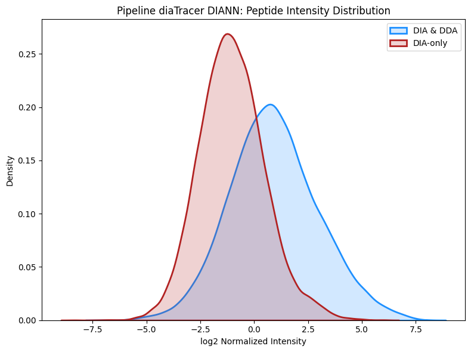

```
VSLLKEL matched ['sp|P53355|DAPK1_HUMAN', 'sp|Q8TED0|UTP15_HUMAN', 'sp|A6NLU0|RFPLA_HUMAN', 'tr|B4DHI4|B4DHI4_HUMAN', 'sp|F8VTS6|RFAL1_HUMAN', 'tr|Q59H88|Q59H88_HUMAN', 'sp|Q96MR6|CFA57_HUMAN', 'tr|H0Y8P4|H0Y8P4_HUMAN', 'sp|P53355-3|DAPK1_HUMAN', 'sp|P53355-4|DAPK1_HUMAN', 'tr|A0A087WVY5|A0A087WVY5_…
```

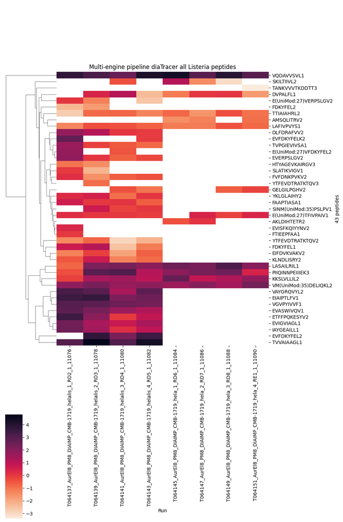

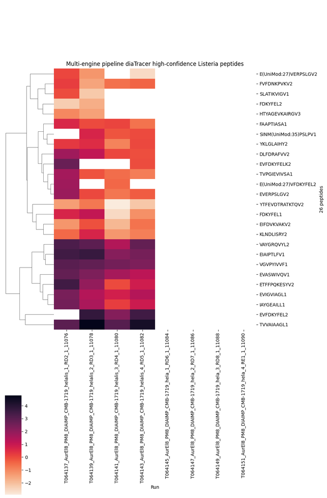

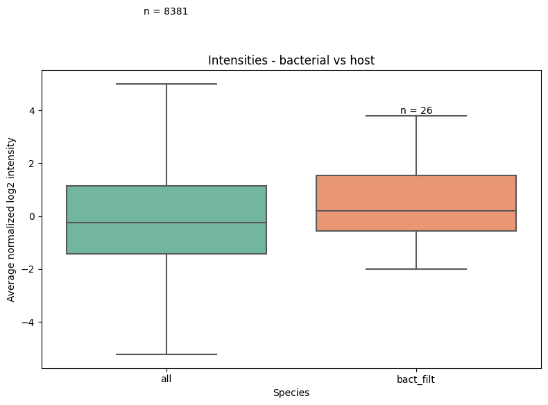

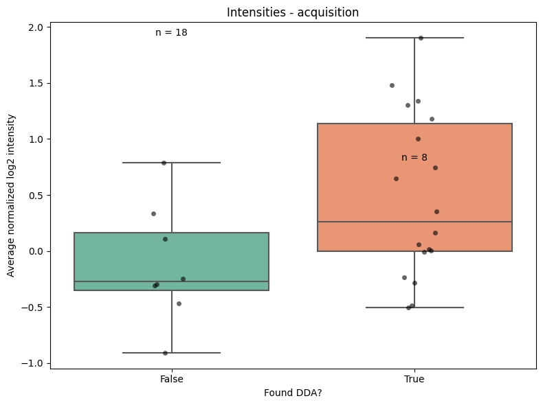

```python
import pandas as pd
import numpy as np
from Bio import SeqIO
from tqdm import tqdm
import sys

# We will re-map the stripped.sequences.
fasta_path = 'EGD_human.fasta'
records = list(SeqIO.parse(fasta_path, "fasta"))
fasta_dict = {record.id: str(record.seq) for record in records}

# Read DIA-NN main report and get unique sequences.
df = pd.read_parquet('pipeline_diann_report.parquet')
pipeline_peps = set(df["Stripped.Sequence"].unique())

# Map the sequences to proteins
mapping_dict = {}
for pep in tqdm(pipeline_peps, desc="Mapping peptides to proteins"):
    matching_proteins = [prot_id for prot_id, seq in fasta_dict.items() if pep in seq]
    mapping_dict[pep] = ";".join(matching_proteins) if matching_proteins else "No_match"
df['Mapped_Proteins'] = df['Stripped.Sequence'].apply(lambda pep: mapping_dict.get(pep, 'No_match'))

# Log2 transform.
df["log2_int"] = np.log2(df["Precursor.Normalised"])

# Peptide found in DDA or not
df['dda'] = df['Stripped.Sequence'].isin(pipelineDDA_peps)

# Pivot intensities.
pivot_df = df.pivot_table(
    index=['Precursor.Id', 'Protein.Ids','Protein.Names','Mapped_Proteins','Genes','Stripped.Sequence','dda'],
    columns='Run',
    values='log2_int'
)

# Median normalize per sample (column-wise)
pivot_df = pivot_df.subtract(pivot_df.median(axis=0), axis=1)

# Save matrix.
pivot_df.to_csv('Pipeline_diaTracer_DIANN_matrix.tsv',sep='\t') # Save values.

# Density plot of DIA-only peptides and those also found by ddaPASEF.
dia_dda = pivot_df[pivot_df.index.get_level_values('dda')].values.flatten()
dia_only = pivot_df[~pivot_df.index.get_level_values('dda')].values.flatten()
dia_dda = dia_dda[~np.isnan(dia_dda)]
dia_only = dia_only[~np.isnan(dia_only)]
plt.figure(figsize=(8, 6))
sns.kdeplot(dia_dda, fill=True, label="DIA & DDA", color="dodgerblue", linewidth=2, alpha=0.2)
sns.kdeplot(dia_only, fill=True, label="DIA-only", color="firebrick", linewidth=2, alpha=0.2)
plt.xlabel("log2 Normalized Intensity")
plt.ylabel("Density")
plt.title("Pipeline diaTracer DIANN: Peptide Intensity Distribution")
plt.legend()
plt.tight_layout()
plt.savefig('Pipeline_diaTracer_DIANN_int.svg')
plt.savefig('Pipeline_diaTracer_DIANN_int.png', dpi=600)
plt.show()
plt.clf()
plt.close()

## FIGURE 5
# Bacterial peptide filtering
bact_df = pivot_df[
    (pivot_df.index.get_level_values('Mapped_Proteins').str.contains('_LISMG')) &
    (~pivot_df.index.get_level_values('Mapped_Proteins').str.contains('_HUMAN'))
]
pipeline_bact_peps = bact_df.index.get_level_values('Stripped.Sequence').unique()
bact_peptides_ItoL = [pep.replace('I', 'L') for pep in pipeline_bact_peps] # Isobaric

# Filter 1: check for matching human/contaminant/nuORF db protein
bact_peptide_check = {}
for pep in bact_peptides_ItoL:
    matching_proteins = [prot_id for prot_id, seq in protein_dict.items() if pep in seq]

    if matching_proteins:  # If there are any matching proteins
        bact_peptide_check[pep] = matching_proteins
        print(f'{pep} matched {matching_proteins}!')
    else:
        bact_peptide_check[pep] = 'No_match'

# Drop this peptide as it matched a non-bacterial protein.
bact_df = bact_df[~(bact_df.index.get_level_values('Stripped.Sequence') == 'VSLLKEI')]

# Get infected and uninfected and fill in zeroes.
inf_cols = [col for col in bact_df.columns if "_helalis_" in col]
uninf_cols = [col for col in bact_df.columns if "_hela_" in col]
bact_df.fillna(0, inplace=True)  # Set to zero for clustering and filtering, will be masked later.

# Heatmap of all bacterial peptides
mask = bact_df == 0
yticklabels = bact_df.index.get_level_values(0)
g = sns.clustermap(
    bact_df,
    cmap="rocket_r",  # Choose a color map
    col_cluster=False,  # Do not cluster columns (R.FileName)
    figsize=(10, 15),  # Adjust figure size
    mask=mask,
    yticklabels=yticklabels,
    cbar_pos=(0.02, 0, 0.05, 0.2)
)
g.ax_heatmap.set_ylabel(f'{len(bact_df)} peptides')
g.ax_heatmap.set_title('Multi-engine pipeline diaTracer all Listeria peptides')
plt.savefig('Pipeline_diaTracer_DIANN_bact_heatmap_all.svg')
plt.savefig('Pipeline_diaTracer_DIANN_bact_heatmap_all.png',dpi=600)
plt.show()

# Filter 2: at least quantified twice in the infected condition, absent in the uninfected
bact_df_filt = bact_df[
    ((bact_df[inf_cols] != 0).sum(axis=1) >= 2) &  # Quantified twice in infection
    ((bact_df[uninf_cols] == 0).all(axis=1))           # All zero values in hela
]
pipeline_bact_peps_filt = bact_df_filt.index.get_level_values('Stripped.Sequence').unique()
mask = bact_df_filt == 0
yticklabels = bact_df_filt.index.get_level_values(0)
g = sns.clustermap(
    bact_df_filt,
    cmap="rocket_r",  # Choose a color map
    col_cluster=False,  # Do not cluster columns (R.FileName)
    figsize=(10, 15),  # Adjust figure size
    mask=mask,
    yticklabels=yticklabels,
    cbar_pos=(0.02, 0, 0.05, 0.2)
)
g.ax_heatmap.set_ylabel(f'{len(bact_df_filt)} peptides')
g.ax_heatmap.set_title('Multi-engine pipeline diaTracer high-confidence Listeria peptides')
plt.savefig('Pipeline_diaTracer_DIANN_bact_heatmap_filt.svg')
plt.savefig('Pipeline_diaTracer_DIANN_bact_heatmap_filt.png',dpi=600)
plt.show()

# Print out the information of the bacterial peptides ordered as in the clustermap
precursors_plotted = [bact_df_filt.index[i] for i in g.dendrogram_row.reordered_ind]
with open("Pipeline_diaTracer_DIANN_bact_heatmap_filt_ylabels.txt", "w") as f:
    for prec in precursors_plotted:
        f.write("\t".join(map(str, prec)) + "\n")

## Boxplot of quantifications
# High-confidence bacterial peptides versus all peptides
row_means = pivot_df.mean(axis=1, skipna=True)
bact_filt_means = row_means[row_means.index.isin(bact_df_filt.index)]
plot_df = pd.DataFrame({
    'mean_intensity': pd.concat([row_means,bact_filt_means], ignore_index=True),
    'group': (['all'] * len(row_means)) + (['bact_filt'] * len(bact_filt_means))
})

# Plot
plt.figure(figsize=(8, 6))
sns.boxplot(x='group', y='mean_intensity', data=plot_df, palette="Set2",showfliers=False)
plt.title("Intensities - bacterial vs host")
plt.ylabel("Average normalized log2 intensity")
plt.xlabel("Species")
for i, grp in enumerate(['all', 'bact_filt']):
    n = plot_df[plot_df['group'] == grp].shape[0]
    ymax = plot_df[plot_df['group'] == grp]['mean_intensity'].max()
    plt.text(i, ymax, f"n = {n}", ha='center', va='bottom')
plt.tight_layout()
plt.savefig('Pipeline_diaTracer_DIANN_bact_host_int_boxplot.svg')
plt.savefig('Pipeline_diaTracer_DIANN_bact_host_int_boxplot.png',dpi=600)
plt.show()
plt.clf()
plt.close()

# High-confidence bacterial peptides: DDA vs DIA-only spectrum-centric vs uniquely peptide-centric
# Calculate row means
bact_df_filt['row_mean'] = bact_df_filt.mean(axis=1, skipna=True)
df_plot = bact_df_filt.copy()
df_plot = df_plot.reset_index()
# Create plot
plt.figure(figsize=(8, 6))
sns.boxplot(x='dda', y='row_mean', data=df_plot, palette='Set2',showfliers=False)
sns.stripplot(x='dda', y='row_mean', data=df_plot, color='black', alpha=0.6, jitter=True, dodge=True)  # Add jitter (jitter = True)
plt.title('Intensities - acquisition')
plt.xlabel('Found DDA?')
plt.ylabel('Average normalized log2 intensity')

# Add n annotations
for i, grp in enumerate(df_plot['dda'].unique()):
    n = (df_plot['dda'] == grp).sum()
    ymax = df_plot[df_plot['dda'] == grp]['row_mean'].max()
    plt.text(i, ymax, f'n = {n}', ha='center', va='bottom')

plt.tight_layout()
plt.savefig('Pipeline_diaTracer_DIANN_bact_dda_int_boxplot.svg')
plt.savefig('Pipeline_diaTracer_DIANN_bact_dda_int_boxplot.png',dpi=600)
plt.show()
plt.clf()
plt.close()
```

## UpSet plot of identified peptides spectrum-centric processing.

### Indicate the total number of the diaPASEF spectrum-centric processing analyses and compare the overlap to the ddaPASEF analysis.

```
FragPipe: 5985 peptides
Spectronaut: 5963 peptides
Pipeline ddaPASEF: 7032 peptides
Pipeline diaPASEF: 7398 peptides
```

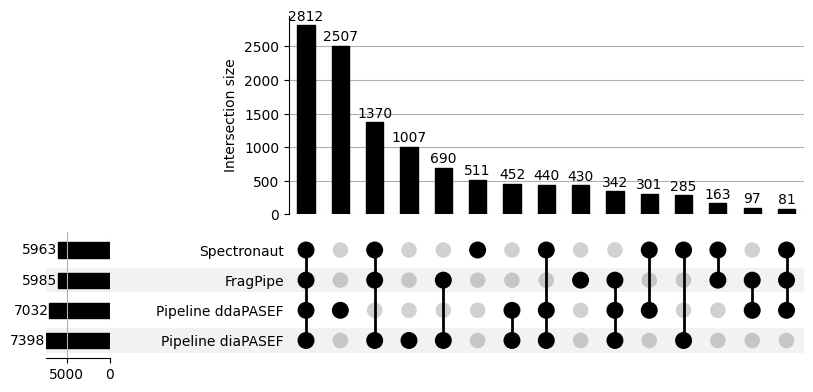

```python
import pandas as pd
from upsetplot import UpSet, from_indicators
import matplotlib.pyplot as plt

# Ensure the peptide lists are sets
print(f'FragPipe: {len(fragpipe_peps)} peptides')
print(f'Spectronaut: {len(spectronaut_peps)} peptides')
print(f'Pipeline ddaPASEF: {len(pipelineDDA_peps)} peptides')
print(f'Pipeline diaPASEF: {len(pipeline_peps)} peptides')

# Get all unique peptides
all_peptides = fragpipe_peps.union(spectronaut_peps, pipelineDDA_peps, pipeline_peps)

# Create dataframe for upset plot.
data = pd.DataFrame({
    "FragPipe": [pep in fragpipe_peps for pep in all_peptides],
    "Spectronaut": [pep in spectronaut_peps for pep in all_peptides],
    "Pipeline diaPASEF": [pep in pipeline_peps for pep in all_peptides],
    "Pipeline ddaPASEF": [pep in pipelineDDA_peps for pep in all_peptides]
}, index=list(all_peptides))  # Use peptides as row index

# Convert to UpSet-compatible format
upset_data = from_indicators(["FragPipe", "Spectronaut","Pipeline ddaPASEF","Pipeline diaPASEF"], data)

# Plot UpSet diagram
UpSet(upset_data,show_counts=True, sort_by="cardinality").plot()
plt.savefig('upset_spectrumCentric.svg')
plt.savefig('upset_spectrumCentric.png',dpi=600)
data.to_csv('upset_spectrumCentric.tsv',sep='\t')
plt.show()
```